# Hypothesis Tests, Analysis of Variance, and Linear Regression

Jeffrey Mansour, 119718025

```r
library(dplyr)
```

# 1 Test Statistics, P-Values, and Errors

We will be working with Hypothesis tests involving population means, when the variance $\sigma^2$ is known.

## 1.1 Functions for Hypothesis Tests

Write the functions that calculate the test statistic $Z$, the $P$-value, the Type II errors, and sample sizes (for a given type II error) for Hypothesis tests of the form
$$H_0: \mu = \mu_0$$
and the three possible Alternative Hypotheses:
$$H_1: \mu <
\mu_0, \quad H_1: \mu > \mu_0, \quad H_1: \mu\neq \mu_0.$$
For upper tailed test:

```r
z_stat_upper <- function(mu_0, samp_mean, samp_size, sigma){
  return(sqrt(samp_size)*(samp_mean - mu_0)/sigma)
}

p_val_upper <- function(test_stat){
  return(1 - pnorm(test_stat))
}

typeII_error_upper <- function(mu_0, mu_a, samp_size, sigma, alpha){
  z_alpha <- qnorm(1 - alpha)
  return(pnorm((z_alpha + ((mu_0 - mu_a)/sigma)*sqrt(samp_size))))
}

sample_size_upper <- function(mu_0, mu_a, sigma, alpha, beta){
  z_alpha <- qnorm(1 - alpha)
  z_beta <- qnorm(1 - beta)
  return(((sigma*((z_alpha + z_beta)/(mu_0 - mu_a))))^2)
}
```

For lower tailed test

```r
z_stat_lower <- function(mu_0, samp_mean, samp_size, sigma){
  return(sqrt(samp_size)*(samp_mean - mu_0)/sigma)
}

p_val_lower <- function(test_stat){
  return(pnorm(test_stat))
}

typeII_error_lower <- function(mu_0, mu_a, samp_size, sigma, alpha){
  z_alpha <- qnorm(1 - alpha)
  return(1 - pnorm((-z_alpha + ((mu_0 - mu_a)/sigma)*sqrt(samp_size))))
}

sample_size_lower <- function(mu_0, mu_a, sigma, alpha, beta){
  z_alpha <- qnorm(1 - alpha)
  z_beta <- qnorm(1 - beta)
  return(((sigma*((z_alpha + z_beta)/(mu_0 - mu_a))))^2)
}
```

For two-tailed test:

```r
z_stat_two_tailed <- function(mu_0, samp_mean, samp_size, sigma){
  return(sqrt(samp_size)*(samp_mean - mu_0)/sigma)
}

p_val_two_tailed <- function(test_stat){
  return(2*(1 - pnorm(abs(test_stat))))
}

typeII_error_two_tailed <- function(mu_0, mu_a, samp_size, sigma, alpha){
  z_alpha <- qnorm(1 - alpha/2)
  return(pnorm((z_alpha + ((mu_0 - mu_a)/sigma)*sqrt(samp_size))) - pnorm((-z_alpha + ((mu_0 - mu_a)/sigma)*sqrt(samp_size))))
}

sample_size_two_tailed <- function(mu_0, mu_a, sigma, alpha, beta){
  z_alpha <- qnorm(1 - alpha/2)
  z_beta <- qnorm(1 - beta)
  return(((sigma*((z_alpha + z_beta)/(mu_0 - mu_a))))^2)
}
```

## 1.2 Simulating a Hypothesis Test

When simulating a Hypothesis test, we will be aware of the value of the true population parameter $\mu$, and will use this to get our random samples of size $n$. Suppose we fix $\mu = 5$, $n=9$, and $\sigma = 1.2$.

The hypothesis test in the simulation will involve working with the knowledge of the null value $\mu_0$, the significance level $\alpha$, the population variance $\sigma^2$, and a possible value $\mu'$ when calculating Type II errors.

### 1.2.1 When $H_0$ is true

In this case we will have the null value to equal the true value, that is $\mu_0 = \mu = 5$.

We now run a simulation to extract replicates of test statistics and P-values on samples coming from $N(5, \sigma = 1.2)$, and store them in the variable test_stats and p_vals respectively.

```r
mu <- 5
mu_0 <- 5
sigma <- 1.2
n <- 9
alpha <- 0.05
test_stats <- numeric(1000)
p_vals <- numeric(1000)
set.seed(123)
for (i in 1:1000) {
  samp <- rnorm(n, mean = mu, sd = sigma)
  test_stats[i] <- (mean(samp) - mu_0) / (sigma / sqrt(n))
  p_vals[i] <- 2*(1 - pnorm(abs(test_stats[i])))
}
```

Use the “mean” function to check the empirical expected value of the test statistic (what do you expect this to be?) and the empirical expected value of the “p_vals”.

```r
print("We expect the value of the t-statistic to be close to 0 because mu_0 = mu = 5 in this scenario")
```

```
## [1] "We expect the value of the t-statistic to be close to 0 because mu_0 = mu = 5 in this scenario"
```

```r
mean(test_stats)
```

```
## [1] 0.008041546
```

```r
mean(p_vals)
```

```
## [1] 0.4945998
```

Plot the histogram of the test_stats to get a visualization of the empirical distribution of the test statistics.

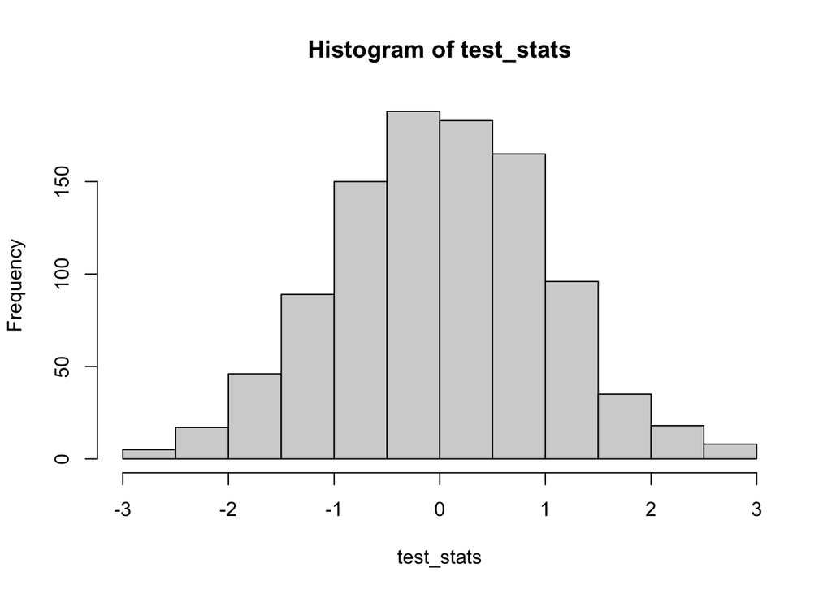

```r
hist(test_stats)
```

What do you notice about the distribution when the Null Hypothesis is true: YOUR ANSWER: The sampling distribution of the test statistics is approximately normal, centered around 0 when the null is true.

Plot the histogram of the “p_vals” to get visualization of the distribution of the P-values. When the null hypothesis is true, this distribution will be a uniform distribution.

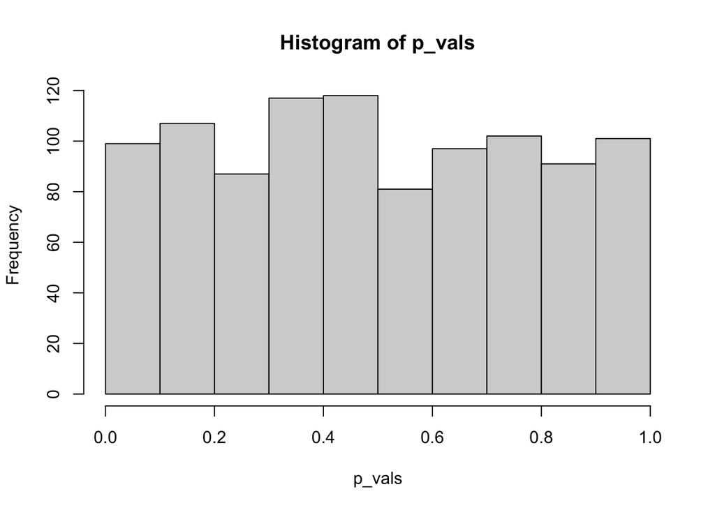

```r
hist(p_vals)
```

Since we already know that the Null Hypothesis is true, the empirical Type I error in this case will be given by all the P-values in “p_vals” that reject the null hypothesis, that is the p_vals that are less than $\alpha \le 0.05$. Calculate the empirical Type I error

```r
count <- 0
for (i in 1:1000) {
  if (p_vals[i] < alpha) {
    count <- count + 1
  }
}
print(count/1000)
```

```
## [1] 0.054
```

Compare this with the theoretical Type I error (it is the significance level). YOUR ANSWER: The empirical Type I error is very close to the theoretical Type I error, since 0.054 is approximately equal to alpha = 0.05. We would expect this empirical value to be close to the theoretical value since the number of samples (1000) is very large.

### 1.2.2 When $H_0$ is not True.

In this case our choice of Null value will not equal the true population parameter $\mu$.

Suppose we assume that $\mu_0 = 4.5$ in the above setting.

We now run a simulation to extract replicates of test statistics and P-values on samples coming from $N(5, \sigma = 1.2)$, and store them in the variable test_stats and p_vals respectively.

```r
mu <- 5
mu_0 <- 4.5
sigma <- 1.2
n <- 9
alpha <- 0.05
test_stats <- numeric(1000)
p_vals <- numeric(1000)
set.seed(123)
for (i in 1:1000) {
  samp <- rnorm(n, mean = mu, sd = sigma)
  test_stats[i] <- (mean(samp) - mu_0) / (sigma / sqrt(n))
  p_vals[i] <- pnorm(test_stats[i]) #assuming lower-tailed test
}
```

Use the “mean” function to check the empirical expected value of the test statistic (what do you expect this to be?) and the empirical expected value of the “p_vals”.

```r
print("We expect the value of the t-statistic to be close to sqrt(n) * (mu - mu_0)/sigma = sqrt(9) * (5 - 4.5)/1.2 = 1.25")
```

```
## [1] "We expect the value of the t-statistic to be close to sqrt(n) * (mu - mu_0)/sigma = sqrt(9) * (5 - 4.5)/1.2 = 1.25"
```

```r
mean(test_stats)
```

```
## [1] 1.258042
```

```r
mean(p_vals)
```

```
## [1] 0.8117447
```

Plot the histogram of the test_stats to get a visualization of the empirical distribution of the test statistics.

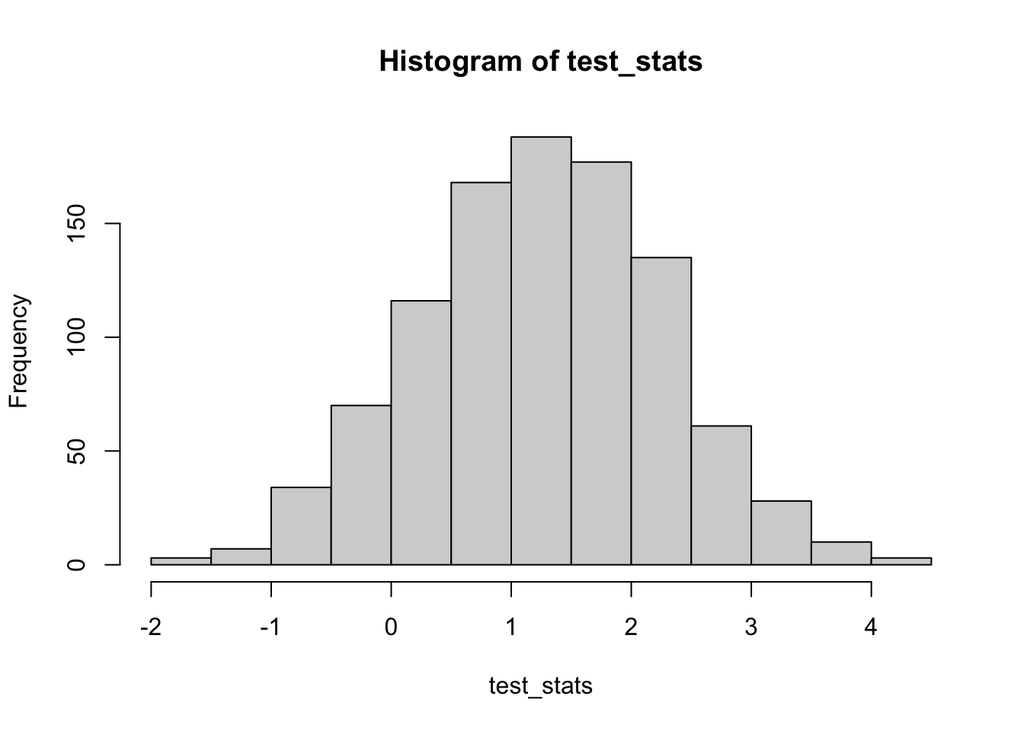

```r
hist(test_stats)
```

What do you notice about the distribution when the Null Hypothesis is false: YOUR ANSWER: The sampling distribution of the test statistics is approximately normal, centered around sqrt(n) * (mu - mu_0)/sigma when the null is false.

Plot the histogram of the “p_vals” to get visualization of the distribution of the P-values. In this case, because the null hypothesis is false, the distribution of the P-values will be skewed.

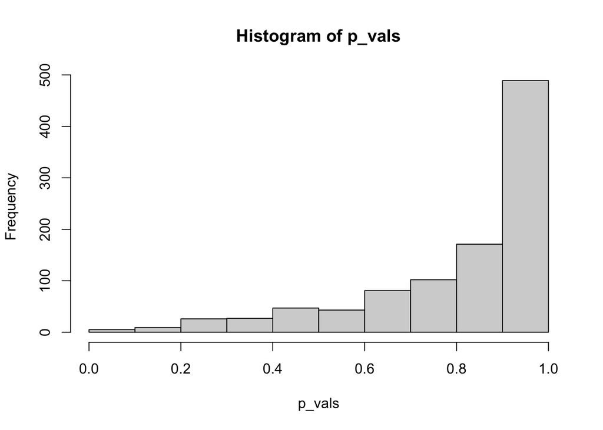

```r
hist(p_vals)
```

Since we know that the Null Hypothesis is false, the empirical Type II error in this case will be given by all the P-values in “p_vals” that fail to reject the null hypothesis, that the p_vals that are greater than $\alpha \le 0.05$.

```r
count <- 0
for (i in 1:1000) {
  if (p_vals[i] > alpha) {
    count <- count + 1
  }
}
print(count/1000)
```

```
## [1] 0.999
```

Use the function you wrote ‘type_II_error_lower’ to calculate the theoretical Type-II error in this case, and compare this with the empirical type-II error calculated above.

```r
typeII_error_lower(4.5, 5, 9, 1.2, 0.05)
```

```
## [1] 0.9981033
```

The empirical Type II error is very close to the theoretical Type II error, since 0.999 is approximately equal to P(Type II error) = 0.9981033. We would expect this empirical value to be close to the theoretical value since the number of samples (1000) is very large.

# 2 Analysis of Type II errors

Suppose we are in the setting where population is normally distributed and population variance is known. \ Write a function that takes input: $\sigma$, $\alpha$ (the significance level), and $n$ (the sample size), and $d = |\mu_0-\mu'|$ and outputs the probability of making a Type II error - $\beta(\mu')$ for the alternative hypothesis $H_a: \mu > \mu_0$.

```r
typeII_error <- function(d, n, sigma, alpha) {
  z_alpha <- qnorm(1 - alpha)
  return(pnorm((z_alpha - (d/sigma)*sqrt(n)))) #note since d = |mu0 - mu'| and mu0 - mu' < 0 in an upper-tailed test, we have a minus sign
}
```

Keeping $n = 10$, $\alpha = 0.05$, and $\sigma = 2$, plot the graph of the $\beta(\mu')$ (y-axis), as a function of $d= |\mu'-\mu_0|$

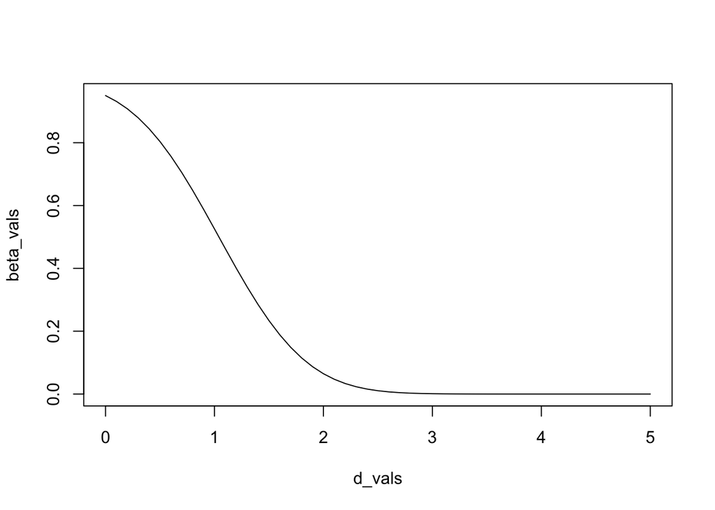

```r
d_vals <- seq(0, 5, by = 0.1)
beta_vals <- numeric(length(d_vals))
for (i in 1:length(beta_vals)) {
  beta_vals[i] <- typeII_error(d_vals[i], 10, 2, 0.05)
}
plot(d_vals, beta_vals, type = "l")
```

What do you notice happening to $\beta(\mu')$ as $d$ becomes large? YOUR ANSWER: As the difference between the null value and the true value of the mean increases, the probability of making a Type II error becomes smaller, approaching 0.

Keeping $d = 0.05$, $\alpha = 0.05$, and $\sigma = 2$, plot the graph of the $\beta(\mu')$ (y-axis), as a function of $n$ the sample size.

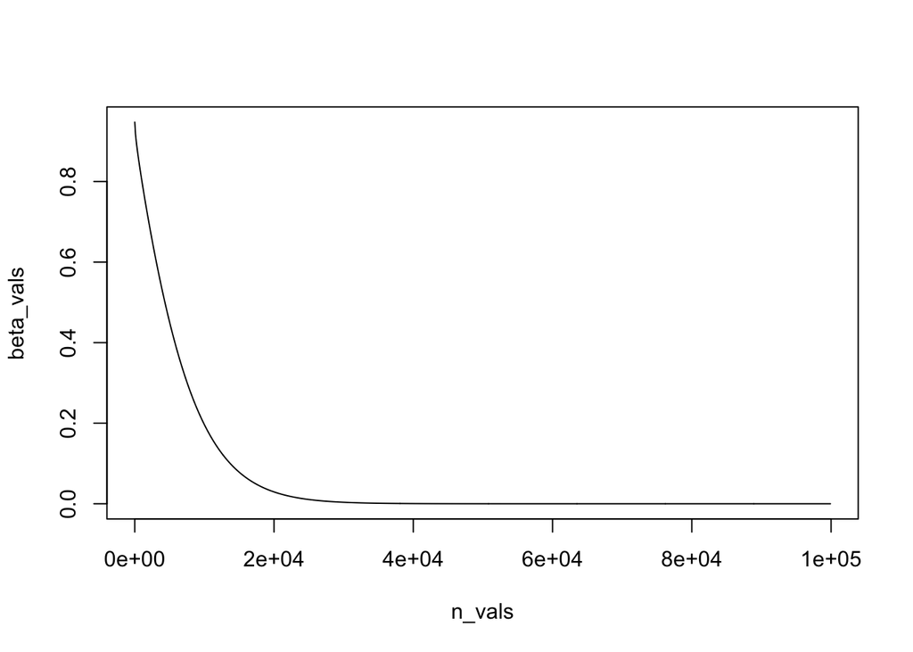

```r
n_vals <- seq(1, 100000, by = 100)
beta_vals <- numeric(length(n_vals))
for (i in 1:length(beta_vals)) {
  beta_vals[i] <- typeII_error(0.05, n_vals[i], 2, 0.05)
}
plot(n_vals, beta_vals, type = "l")
```

What do you notice happening to $\beta(\mu')$ as $n$ becomes large? YOUR ANSWER: As the sample size increases, the probability of making a Type II error becomes smaller, approaching 0.

# 3 Functions for Two-Sample t-test

Write the following functions associated to the two-sample t-test. 1) calculating the t-statistic - will take input: two sample data, and null value. 2) calculating the ‘degrees of freedom’ of the t-statistic - will take input the two sample sizes. 3) calculating the p-value: will take input the t-statistic, and a categorical variable specifying upper, lower, or two-tailed test.

```r
two_samp_t_stat <- function(sample1, sample2, delta_0) {
  mean1 <- mean(sample1)
  mean2 <- mean(sample2)
  sd1 <- sd(sample1)
  sd2 <- sd(sample2)
  m <- length(sample1)
  n <- length(sample2)
  t_stat <- ((mean1 - mean2 - delta_0) / sqrt((sd1^2)/m + (sd2^2)/n))
  return(t_stat)
}

two_samp_df <- function(sample1, sample2) {
  sd1 <- sd(sample1)
  sd2 <- sd(sample2)
  m <- length(sample1)
  n <- length(sample2)
  df <- ((sd1^2)/m + (sd2^2)/n)^2 / (((sd1^2)/m)^2/(m-1) + ((sd2^2)/n)^2/(n-1))
  return(df)
}

two_samp_p_value <- function(t_stat, df, tail = c("lower", "upper", "two")) {
  if (tail == "lower") {
    p_value <- pt(t_stat, df=df)
  } else if (tail == "upper") {
    p_value <- 1 - pt(t_stat, df=df)
  } else if (tail == "two") {
    p_value <- 2*(1 - pt(abs(t_stat), df=df))
  }
  return(p_value)
}
```

# 4 Application to a Plant Growth

Load the inbuilt dataset PlantGrowth from the datasets library in R. This dataset is gives “Results from an experiment to compare yields (as measured by dried weight of plants) obtained under a control and two different treatment conditions.”

Use the two-sample t-test to verify if there is a statistically significant difference in the following cases: 1) control vs treatment1 2) control vs treatment2 3) treatment1 vs treatment2

Do NOT use any stock hypthosis tests already programmed in R. Use the functions you have defined, and extract the relevant responses from the given dataset.

```r
data(PlantGrowth)
control <- PlantGrowth$weight[PlantGrowth$group == "ctrl"]
treatment1 <- PlantGrowth$weight[PlantGrowth$group == "trt1"]
treatment2 <- PlantGrowth$weight[PlantGrowth$group == "trt2"]

t_stat_1 <- (two_samp_t_stat(control, treatment1, 0))
df_1 <- (two_samp_df(control, treatment1))
print(t_stat_1)
```

```
## [1] 1.19126
```

```r
print(df_1)
```

```
## [1] 16.52359
```

```r
print(two_samp_p_value(t_stat_1, df_1, "two"))
```

```
## [1] 0.2503825
```

```r
t_stat_2 <- (two_samp_t_stat(control, treatment2, 0))
df_2 <- (two_samp_df(control, treatment2))
print(t_stat_2)
```

```
## [1] -2.13402
```

```r
print(df_2)
```

```
## [1] 16.78576
```

```r
print(two_samp_p_value(t_stat_2, df_2, "two"))
```

```
## [1] 0.04789926
```

```r
t_stat_3 <- (two_samp_t_stat(treatment1, treatment2, 0))
df_3 <- (two_samp_df(treatment1, treatment2))
print(t_stat_3)
```

```
## [1] -3.010099
```

```r
print(df_3)
```

```
## [1] 14.10357
```

```r
print(two_samp_p_value(t_stat_3, df_3, "two"))
```

```
## [1] 0.009298405
```

# 5 Simulating ANOVA

In this section we will write various functions involved in Analysis of Variance. To keep things simple, we will specify $I$, the number of levels for our ANOVA up front. It is possible to write code that does not need this assumption, but that would be too much R!

Assume that $I=4$ for the rest of the project.

## 5.1 The Test statistics: MSTr and MSE

Write function “MSTr” and “MSE” that take input as four vectors of equal length and output the values for “MSTr” and “MSE”

```r
MSTr = function(v_1, v_2, v_3, v_4){
  dat = rbind(v_1, v_2, v_3, v_4)
  X_bar_i = apply(dat, 1, mean)
  J = ncol(dat)
  return( J/(4-1)*sum((X_bar_i - mean(X_bar_i))^2) )
}

MSE = function(v_1, v_2, v_3, v_4){
  dat = rbind(v_1, v_2, v_3, v_4)
  Sd_i = apply(dat, 1, sd)
  return( mean(Sd_i^2) )
}
```

## 5.2 Unbiasedness of the estimators: MSTr and MSE

We will check the unbiasedness of the estimators when the null hypothesis for ANOVA is true and when the Null Hypothesis is False.

### 5.2.1 $H_0$ is true.

We first work in the setting when the null hypothesis for the ANOVA test is true. Assume that all the four population means equal to $\mu = 2.5$, and we sample from populations with standard deviation $\sigma = 1.2$.

Set up an experiment to show that both MSTr and MSE are unbiased estimators for $\sigma^2$ in this case. Work with $J=10$.

```r
MSTr_samp = function(n){
  v_1 = rnorm(n, 2.5, 1.2)
  v_2 = rnorm(n, 2.5, 1.2)
  v_3 = rnorm(n, 2.5, 1.2)
  v_4 = rnorm(n, 2.5, 1.2)
  return(MSTr(v_1, v_2, v_3, v_4))
}

MSE_samp = function(n){
  v_1 = rnorm(n, 2.5, 1.2)
  v_2 = rnorm(n, 2.5, 1.2)
  v_3 = rnorm(n, 2.5, 1.2)
  v_4 = rnorm(n, 2.5, 1.2)
  return(MSE(v_1, v_2, v_3, v_4))
}

set.seed(123)
MSTr_res = replicate(10000, MSTr_samp(10))
mean(MSTr_res) #close to sigma^2
```

```
## [1] 1.445411
```

```r
MSE_res = replicate(10000, MSE_samp(10))
mean(MSE_res) #close to sigma^2
```

```
## [1] 1.438345
```

```r
mean(MSTr_res)/mean(MSE_res)
```

```
## [1] 1.004913
```

### 5.2.2 $H_0$ is False.

Set up an experiment to show that in this case MSE is an unbiased estimator for $\sigma^2$, but MSTr is not an unbiased estimator for $\sigma^2$. What is the empirical bias of MSTr in this case. Work with $J=10$.

```r
MSTr_samp = function(n){
  v_1 = rnorm(n, 2, 1.2)
  v_2 = rnorm(n, 2.2, 1.2)
  v_3 = rnorm(n, 2.8, 1.2)
  v_4 = rnorm(n, 3.2, 1.2)
  return(MSTr(v_1, v_2, v_3, v_4))
}

MSE_samp = function(n){
  v_1 = rnorm(n, 2, 1.2)
  v_2 = rnorm(n, 2.2, 1.2)
  v_3 = rnorm(n, 2.8, 1.2)
  v_4 = rnorm(n, 3.2, 1.2)
  return(MSE(v_1, v_2, v_3, v_4))
}

set.seed(123)
MSTr_res = replicate(10000, MSTr_samp(10))
mean(MSTr_res) #not close to sigma^2
```

```
## [1] 4.487863
```

```r
MSE_res = replicate(10000, MSE_samp(10))
mean(MSE_res) #close to sigma^2
```

```
## [1] 1.438345
```

```r
mean(MSTr_res)/mean(MSE_res)
```

```
## [1] 3.120157
```

# 6 Application of ANOVA to Plant Growth Dataset

Load the inbuilt dataset PlantGrowth from the datasets library in R. This dataset is gives “Results from an experiment to compare yields (as measured by dried weight of plants) obtained under a control and two different treatment conditions.”

Use your MSTr and MSE functions to this dataset, and cacluate the relevant $F$ statistic.

```r
data(PlantGrowth)
control <- PlantGrowth$weight[PlantGrowth$group == "ctrl"]
treatment1 <- PlantGrowth$weight[PlantGrowth$group == "trt1"]
treatment2 <- PlantGrowth$weight[PlantGrowth$group == "trt2"]

#have to slightly alter MSTr and MSE functions since I=3 here (control, treatment 1, treatment 2)
MSTr = function(v_1, v_2, v_3){
  dat = rbind(v_1, v_2, v_3)
  X_bar_i = apply(dat, 1, mean)
  J = ncol(dat)
  return( J/(3-1)*sum((X_bar_i - mean(X_bar_i))^2) )
}

MSE = function(v_1, v_2, v_3){
  dat = rbind(v_1, v_2, v_3)
  Sd_i = apply(dat, 1, sd)
  return( mean(Sd_i^2) )
}

MSTr_plant <- MSTr(control, treatment1, treatment2)
MSE_plant <- MSE(control, treatment1, treatment2)
F_stat_plant <- MSTr_plant / MSE_plant
print(F_stat_plant)
```

```
## [1] 4.846088
```

Calculate the $P$ value, and state your test result.

```r
I <- 3
J <- 30
df1 <- I - 1 #numerator degrees of freedom (I - 1)
df2 <- I(J - 1)  #denominator degrees of freedom I(J - 1)
p_value <- 1 - pf(F_stat_plant, df1, df2)
print(p_value)
```

```
## [1] 0.01528394
```

```r
print("Reject H0 at alpha = 0.05 signficance")
```

```
## [1] "Reject H0 at alpha = 0.05 signficance"
```

If you reject the null hypothesis, do Tukey’s multiple comparison analysis.

Do NOT use any stock hypothesis tests already programmed in R. Use only the functions you have defined.

```r
df1 <- I #numerator degrees of freedom I
df2 <- I(J - 1)  #denominator degrees of freedom I(J - 1)
q_alpha <- qtukey(1 - alpha, df1, df2)

cntrl_v_tr1 <- mean(control) - mean(treatment1)
p_value_cvtr1 = abs(cntrl_v_tr1) > q_alpha*sqrt(MSE_plant/J)

cntrl_v_tr2 <- mean(control) - mean(treatment2)
p_value_cvtr2 = abs(cntrl_v_tr2) > q_alpha*sqrt(MSE_plant/J)

tr1_v_tr2 <- mean(treatment1) - mean(treatment2)
p_value_tr1vtr2 = abs(tr1_v_tr2) > q_alpha*sqrt(MSE_plant/J)

print(cntrl_v_tr1)
```

```
## [1] 0.371
```

```r
print(p_value_cvtr1)
```

```
## [1] FALSE
```

```r
print(cntrl_v_tr2)
```

```
## [1] -0.494
```

```r
print(p_value_cvtr2)
```

```
## [1] TRUE
```

```r
print(tr1_v_tr2)
```

```
## [1] -0.865
```

```r
print(p_value_tr1vtr2)
```

```
## [1] TRUE
```

# 7 Application ANOVA to the Iris Dataset

We will now apply Analysis of Variance to see if there is difference between different species with regards to different variables (reponses) available in the dataset. The factor in this case will be Species and the levels are: setosa, virginica, and versicolor. Note that there are inbuilt functions in R to run these procedures, however, will build everything that we need.

Load the data set iris:

```r
data("iris")
```

Play around with the different features of this dataset.

## 7.1 Petal Length as Response.

Extract the relevant vectors from the iris dataset corresponding to the response variable being ‘petal length’. Note you will have three vectors of lenght 50.

```r
setosa_length <- iris$Petal.Length[iris$Species == "setosa"]
versicolor_length <- iris$Petal.Length[iris$Species == "versicolor"]
virginica_length <- iris$Petal.Length[iris$Species == "virginica"]
```

Now use the functions you defined, to calculate MSTr, MSE, and the F-statistic.

```r
MSTr_length <- MSTr(setosa_length, versicolor_length, virginica_length)
MSE_length <- MSE(setosa_length, versicolor_length, virginica_length)
F_stat_length <- MSTr_length / MSE_length
print(F_stat_length)
```

```
## [1] 1180.161
```

Identify the relevant parameter for the F-distribution that you will use to calculate the P-value. Calculate the P-value.

```r
I <- 3
J <- 50
df1 <- I - 1 #numerator degrees of freedom (I - 1)
df2 <- I(J - 1)  #denominator degrees of freedom I(J - 1)
p_value <- 1 - pf(F_stat_length, df1, df2)
print(p_value)
```

```
## [1] 0
```

What is the test decision? YOUR ANSWER: Reject H0 at alpha = 0.05 signficance

If you rejected the Null Hypothesis, perform Tukey’s multiple comparisons to identify the significantly different $\mu$’s.

```r
df1 <- I #numerator degrees of freedom I
df2 <- I(J - 1)  #denominator degrees of freedom I(J - 1)
q_alpha <- qtukey(1 - alpha, df1, df2)

set_v_versi <- mean(setosa_length) - mean(versicolor_length)
p_value_set_v_versi = abs(set_v_versi) > q_alpha*sqrt(MSE_length/J)

set_v_virg <- mean(setosa_length) - mean(virginica_length)
p_value_set_v_virg = abs(set_v_virg) > q_alpha*sqrt(MSE_length/J)

versi_v_virg <- mean(versicolor_length) - mean(virginica_length)
p_value_versi_v_verg = abs(versi_v_virg) > q_alpha*sqrt(MSE_length/J)

print(set_v_versi)
```

```
## [1] -2.798
```

```r
print(p_value_set_v_versi)
```

```
## [1] TRUE
```

```r
print(set_v_virg)
```

```
## [1] -4.09
```

```r
print(p_value_set_v_virg)
```

```
## [1] TRUE
```

```r
print(versi_v_virg)
```

```
## [1] -1.292
```

```r
print(p_value_versi_v_verg)
```

```
## [1] TRUE
```

## 7.2 Sepal Width as Response.

Perform the same procedure as above with the new response variable being ‘sepal width’.

```r
setosa_width <- iris$Sepal.Width[iris$Species == "setosa"]
versicolor_width <- iris$Sepal.Width[iris$Species == "versicolor"]
virginica_width <- iris$Sepal.Width[iris$Species == "virginica"]

MSTr_width <- MSTr(setosa_width, versicolor_width, virginica_width)
MSE_width <- MSE(setosa_width, versicolor_width, virginica_width)
F_stat_width <- MSTr_width / MSE_width
print(F_stat_width)
```

```
## [1] 49.16004
```

```r
I <- 3
J <- 50
df1 <- I - 1 #numerator degrees of freedom (I - 1)
df2 <- I(J - 1)  #denominator degrees of freedom I(J - 1)
p_value <- 1 - pf(F_stat_width, df1, df2)
print(p_value) #Reject H0 at alpha = 0.05 signficance
```

```
## [1] 1.938227e-12
```

```r
df1 <- I #numerator degrees of freedom I
df2 <- I(J - 1)  #denominator degrees of freedom I(J - 1)
q_alpha <- qtukey(1 - alpha, df1, df2)

#Tukey's
set_v_versi <- mean(setosa_width) - mean(versicolor_width)
p_value_set_v_versi = abs(set_v_versi) > q_alpha*sqrt(MSE_width/J)

set_v_virg <- mean(setosa_width) - mean(virginica_width)
p_value_set_v_virg = abs(set_v_virg) > q_alpha*sqrt(MSE_width/J)

versi_v_virg <- mean(versicolor_width) - mean(virginica_width)
p_value_versi_v_verg = abs(versi_v_virg) > q_alpha*sqrt(MSE_width/J)

print(set_v_versi)
```

```
## [1] 0.658
```

```r
print(p_value_set_v_versi)
```

```
## [1] TRUE
```

```r
print(set_v_virg)
```

```
## [1] 0.454
```

```r
print(p_value_set_v_virg)
```

```
## [1] TRUE
```

```r
print(versi_v_virg)
```

```
## [1] -0.204
```

```r
print(p_value_versi_v_verg)
```

```
## [1] TRUE
```

# 8 Linear Regression

Recall that random samples for simple regression look like $\{(x_i, Y_i)\; | \;\;Y_i = \alpha + \beta x_i + \epsilon_i \}$. Note that $\alpha, \beta$ and $\sigma$ are model parameters and $\{\epsilon_i \;\;| \;\; \epsilon_i \sim N(0, \sigma^2), i = 1, 2, 3, \dots, n. \}$

## 8.1 Setup the random samples

Suppose we are working with a simple linear model with parameters:
$$\alpha = 3, \beta = 5, \sigma =
1.6$$

We also need fixe a set of ‘x-values’ we will call them x_fixed

```r
x_fixed <- seq(0, 10, by=0.5)
alpha <- 3
beta <- 5
sigma <- 1.6
```

Construct the random variable that generates the sample data for our model:

```r
Y <- function(x_vec, alpha, beta, sigma){
  y = c()
  for(x in x_vec){
    temp <- alpha + beta*x+rnorm(1, mean = 0,  sd = sigma)
    y <- c(y, temp)
  }
   return(y)
}
Y(x_fixed, 3, 5, 1.6)
```

```
##  [1]  2.144490  7.038312  6.233664 10.731216 12.619679 13.987565 18.642222
##  [8] 21.459198 24.358277 24.280683 24.724022 32.534327 34.566529 33.682650
## [15] 38.544371 39.991143 42.833860 44.159032 48.475887 49.659655 52.997503
```

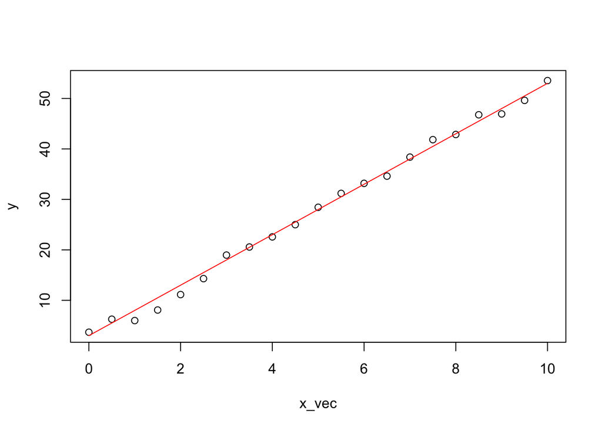

```r
plot_Y <- function(x_vec, alpha, beta, sigma){
  y <- Y(x_vec, alpha, beta, sigma)
  plot(x_vec, y)
  lines(x_vec, alpha + beta*x_fixed,
        col='red')
  }

plot_Y(x_fixed, alpha, beta, sigma)
```

## 8.2 Define the statistics

Define the statistics that take input two vectors $x_{\text{fixed}}$ and $y$ and output estimates for (1) the slope parameter, (2) the intercept parameter, (3) the variance parameter, (4) the prediction for a given value of x.

```r
S_xx <- function(x){
  return(sum((x-mean(x))^2))
}

S_xy <- function(x, y){
  return(sum((x-mean(x))*(y-mean(y))))
}


b_hat <- function(x,y){
  return(S_xy(x,y)/S_xx(x))
}

a_hat <- function(x, y){
  return(mean(y) - b_hat(x,y)*mean(x))
}

sig_hat_squared <- function(x, y){
  n <- length(x)
  return((S_xx(y) - b_hat(x, y)*S_xy(x, y))/(n-2))
}

y_hat <- function(x, y, x_0){
  return(a_hat(x,y) + b_hat(x,y)*x_0)
}
```

Get the estimated regression line

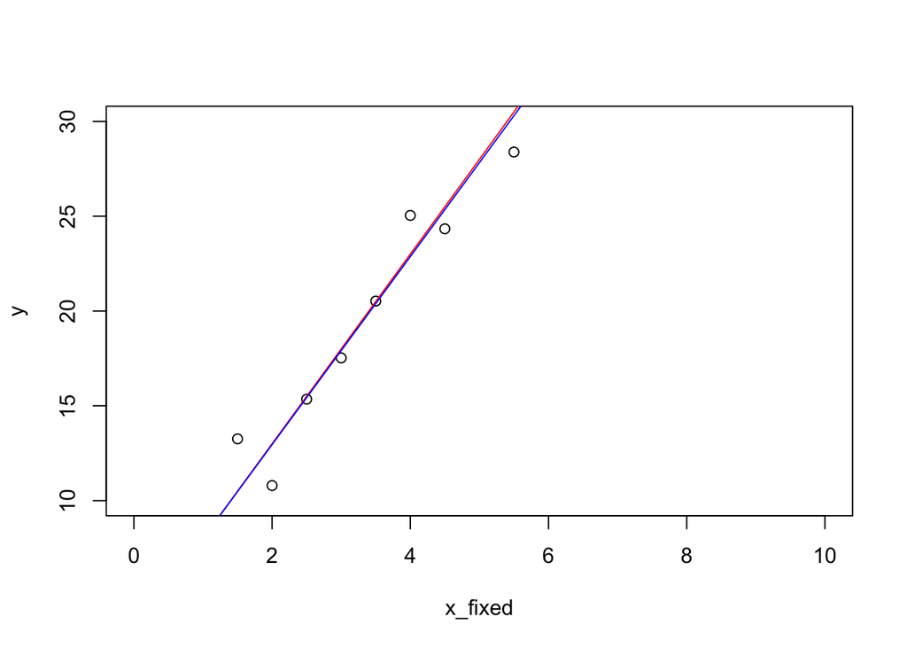

```r
plot_Y_with_yhat <- function(x_fixed, alpha, beta, sigma){
  y <- Y(x_fixed, alpha, beta, sigma)
  a <- a_hat(x_fixed, y)
  b <- b_hat(x_fixed, y)
  y_hat <- a + b*x_fixed

  plot(x_fixed, y,
       ylim = c(10, 30))
  lines(x_fixed, alpha + beta*x_fixed,
        col='red')
  lines(x_fixed, y_hat,
        col = 'blue')
  }

plot_Y_with_yhat(x_fixed, alpha, beta, sigma)
```

The next section of code plots 40 estimated regression lines coming from 40 different sample data for linear regression. I showed this plot in class, it is also available in the textbook.

Play around with the code to get the relevant plot.

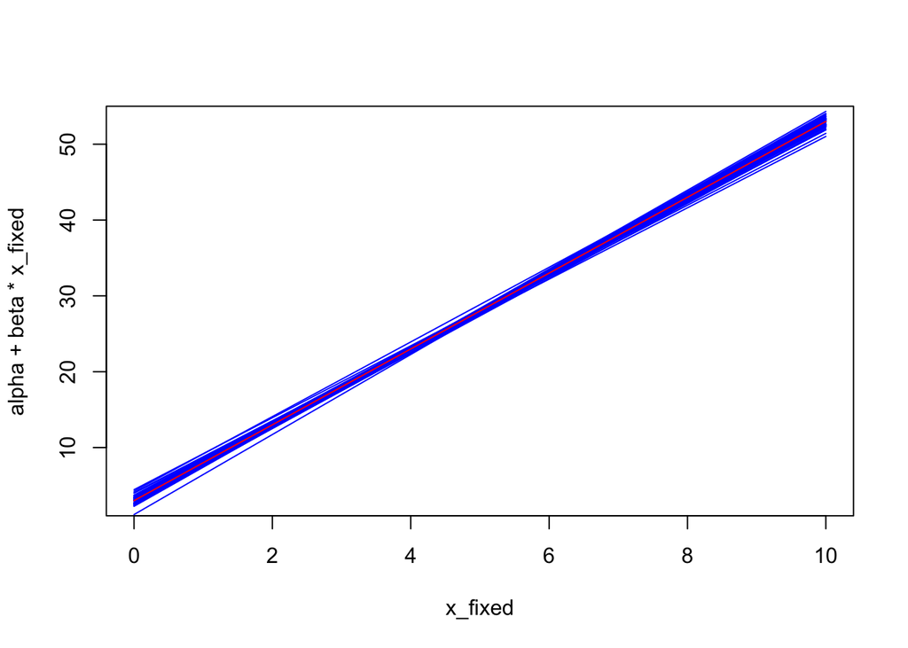

```r
plot_y_hats <-  function(x_fixed, alpha, beta, sigma){
  plot(x_fixed, alpha + beta*x_fixed,
        col='red',
       type = 'l') #true regression line
  for(i in 1:40){
    y <- Y(x_fixed, alpha, beta, sigma)
    a <- a_hat(x_fixed, y)
    b <- b_hat(x_fixed, y)
    y_hat <- a + b*x_fixed
    lines(x_fixed, y_hat,
        col = 'blue')
  }
   lines(x_fixed, alpha + beta*x_fixed,
        col='red')
}


plot_y_hats(x_fixed, alpha, beta, sigma)
```

## 8.3 Sampling distribution and CI for $\hat{Y}$

We will run a simulation for the 95% CI of the statistic $\hat{Y}$.

### 8.3.1 The relevant test statistic

Define the relevant test statistic $T$ for $\hat{Y}$. You will have to define function to calculate $S_{\hat{Y}}$ first.

```r
x_fixed <- seq(1, 10, by =0.5)
alpha <- 3
beta <- 2
sigma <- 1.5

Y <- function(x_vec, alpha, beta, sigma){
  y = c()
  for(x in x_vec){
    temp <- alpha + beta*x+rnorm(1, mean = 0,  sd = sigma)
    y <- c(y, temp)
  }
   return(y)
}

S_xx <- function(x){
  return(sum((x-mean(x))^2))
}

S_xy <- function(x, y){
  return(sum((x-mean(x))*(y-mean(y))))
}

b_hat <- function(x,y){
  return(S_xy(x,y)/S_xx(x))
}


a_hat <- function(x, y){
  return(mean(y) - b_hat(x,y)*mean(x))
}

sig_hat_squared <- function(x, y){
  n <- length(x)
  return((S_xx(y) - b_hat(x, y)*S_xy(x, y))/(n-2))
}

y_hat <- function(x, y, x_0){
  return(a_hat(x,y) + b_hat(x,y)*x_0)
}
```

### 8.3.2 Define CI function

Define a function that takes input $x_{fixed}$, $y$, and a value $x^*$, and outputs the 95% CI for $\hat{Y}(x^*)$.

Need (1) the estimated regression line, variance in $\hat{Y}$

```r
CI95_for_Ygiven_x <- function(x_fixed, y_s, x) {
  n <- length(x_fixed)
  x_bar <- mean(x_fixed)
  s <- sqrt(sig_hat_squared(x_fixed, y_s))
  error <- s*sqrt((1/n + ((x - x_bar)^2)/S_xx(x_fixed)))
  t <- qt(0.025, df= n-2, lower.tail = FALSE)
  y_h <- y_hat(x_fixed, y_s, x)
  CI <- y_h + error*c(-t, t)
  return(CI)
}
```

Get a sample data pair $(x_{fixed}, y_{fixed})$ using the function “Y” defined above and then calculate 95% CIs for $x^* = 5.5$ and $x^* = 7.5$.

```r
x_fixed <- seq(1, 10, by =0.5)
alpha <- 3
beta <- 5
sigma <- 1.6

Y <- function(x_vec, alpha, beta, sigma){
  y = c()
  for(x in x_vec){
    temp <- alpha + beta*x+rnorm(1, mean = 0,  sd = sigma)
    y <- c(y, temp)
  }
   return(y)
}

y = Y(x_fixed, alpha, beta, sigma)

diff(CI95_for_Ygiven_x(x_fixed, y, 5.5))
```

```
## [1] 1.576844
```

```r
diff(CI95_for_Ygiven_x(x_fixed, y, 7.5))
```

```
## [1] 1.952572
```

What do you notice about the width of these two intervals? YOUR ANSWER: The width of the interval is larger when x* = 7.5 than when x* = 5.5

### 8.3.3 95% CI simulation

Use the replicates function and the fact that $T$ has Student’s t-distribution with $n-2$ degrees of freedom to run a simulation to show that indeed 95% of CI’s will contain $Y(x^*)$ when $x^* = 5$ and when $x^* = 7$.

```r
library(dplyr)
mean_inside_CI <- function(CI, mu){
  l <- CI[1]
  u <- CI[2]
  return(between(mu, l, u))
}

alpha <- 3
beta <- 5
sigma <- 1.6

Y_5 = alpha + beta*5
Y_7 = alpha + beta*7

sample_t_5 <- function(n){
  x_fixed = sample(seq(-20, 20, by = 1), n)
  y = Y(x_fixed, alpha, beta, sigma)
  CI <- CI95_for_Ygiven_x(x_fixed, y, 5)
  return(mean_inside_CI(CI,Y_5))
}

sample_t_7 <- function(n){
  x_fixed = sample(seq(-20, 20, by = 1), n)
  y = Y(x_fixed, alpha, beta, sigma)
  CI <- CI95_for_Ygiven_x(x_fixed, y, 7)
  return(mean_inside_CI(CI,Y_7))
}

set.seed(2020)
B <- 10000
n <- 15
CI_95_norm_5 <- replicate(B, sample_t_5(n))
CI_95_norm_7 <- replicate(B, sample_t_7(n))

mean(CI_95_norm_5)
```

```
## [1] 0.9539
```

```r
mean(CI_95_norm_7)
```

```
## [1] 0.9467
```

```r
#working for x^* = 6

x_fixed <- seq(1, 10, by =0.5)
alpha <- 3
beta <- 2
sigma <- 1.5

library(dplyr) #for the function 'between'
x_star <- 5.4
mu <- alpha + beta*x_star
y_hat_reps <- replicate(10000,
                        mean_inside_CI(
                          CI95_for_Ygiven_x(x_fixed, Y(x_fixed, alpha, beta, sigma), x_star), mu
                        ))
CI_lenghts_x <- replicate(10000,
                        diff(
                          CI95_for_Ygiven_x(x_fixed, Y(x_fixed, alpha, beta, sigma), x_star)
                        )
                        )
print(x_star)
```

```
## [1] 5.4
```

```r
mean(CI_lenghts_x)
```

```
## [1] 1.433017
```

```r
mean(y_hat_reps)
```

```
## [1] 0.9522
```

```r
x_star <- 9.5
mu <- alpha + beta*x_star
y_hat_reps <- replicate(10000,
                        mean_inside_CI(
                          CI95_for_Ygiven_x(x_fixed, Y(x_fixed, alpha, beta, sigma), x_star), mu
                        ))
CI_lenghts_x <- replicate(10000,
                        diff(
                          CI95_for_Ygiven_x(x_fixed, Y(x_fixed, alpha, beta, sigma), x_star)
                        )
                        )
print(x_star)
```

```
## [1] 9.5
```

```r
mean(CI_lenghts_x)
```

```
## [1] 2.53268
```

```r
mean(y_hat_reps)
```

```
## [1] 0.9454
```

# 9 Some Help Code

```r
# S_xx <- function(x){
#   return(sum((x-mean(x))^2))
# }
#
# S_xy <- function(x, y){
#   return(sum((x-mean(x))*(y-mean(y))))
# }
#
# b_hat <- function(x,y){
#   return(S_xy(x,y)/S_xx(x))
# }
#
#
# a_hat <- function(x, y){
#   return(mean(y) - b_hat(x,y)*mean(x))
# }
# #
# y_hat <- function(x, y, x_0){
#   return(a_hat(x,y) + b_hat(x,y)*x_0)
# }
#
# alpha <- 5
# beta <- 2
# sig <- 2
#
# x_fixed <- round(seq(3, 8, length.out = 15), 2)
# Y <- function(){
#   y <- c()
#   for(x in x_fixed){
#     temp <- rnorm(1, mean = alpha + beta*x, sd = sig)
#     y <- c(y, temp)
#   }
#   return(y)
# }
#
#
# #If we are given a sample of the form {(x_i, y_i), i =1, 2, 3, ... n}
# Y_hat <- function(samp, x){
#   return(alpha_hat(samp) + beta_hat(samp)*x)
# }
```

#Sampling the Slope parameter

```r
#beta_hats <- replicate(10000, {
#  y <- Y()
#  b_hat(x_fixed, y)
#})
#mean(beta_hats)
#var(beta_hats)
#theoretical_var <- sig^2/S_xx(x_fixed)
#theoretical_var
#hist(beta_hats, breaks = 30)
```